----------------------------

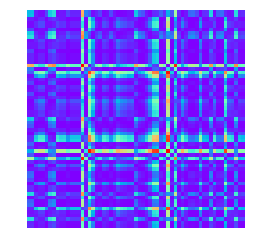

9

A_M1019YF04_2S2RNA

Drowsy True

Window Number 42

----------------------------

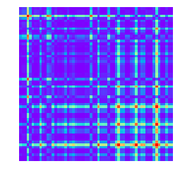

10

A_M1021YF05_2S3RNA

Drowsy True

Window Number 40

----------------------------

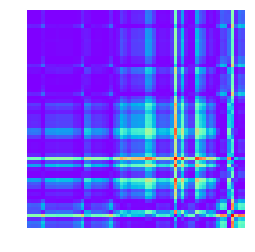

11

A_M1021YF05_2S3RNA

Drowsy True

Window Number 41

----------------------------

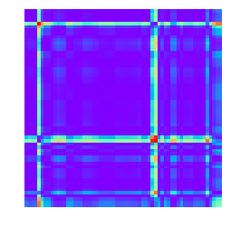

12

A_M1021YF05_2S3RNA

Drowsy True

Window Number 43

----------------------------

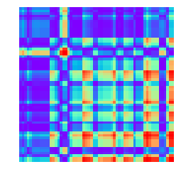

13

A_M1021YF05_2S3RNA

Drowsy True

Window Number 44

----------------------------

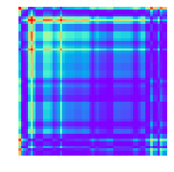

14

A_M1021YF05_3S1RNA

Drowsy True

Window Number 31

----------------------------

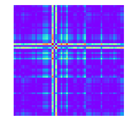

15

A_M1026MM01_3S3RNA

Drowsy True

Window Number 35

----------------------------

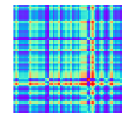

16

A_M1026MM01_3S3RNA

Drowsy True

Window Number 37

----------------------------

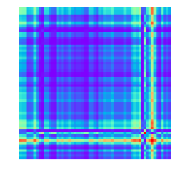

17

A_M1026MM01_3S3RNA

Drowsy True

Window Number 38

----------------------------

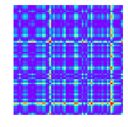

18

A_M1026MM01_3S3RNA

Drowsy True

Window Number 39

----------------------------

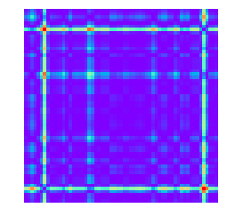

19

A_M1030MM03_3S1RNA

Drowsy True

Window Number 31

----------------------------

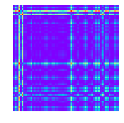

20

A_M1030MM03_3S1RNA

Drowsy True

Window Number 33

----------------------------

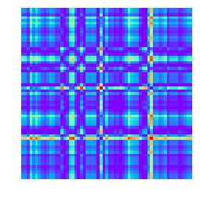

21

A_M1030MM03_3S1RNA

Drowsy True

Window Number 35

----------------------------

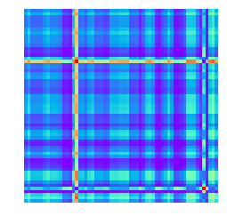

22

A_M1030MM03_3S1RNA

Drowsy True

Window Number 37

----------------------------

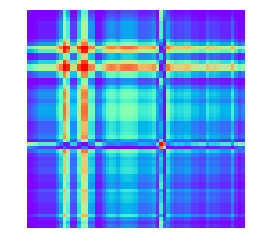

23

A_M1031MM04_2S2RNA

Drowsy True

Window Number 38

----------------------------

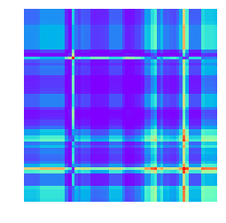

24

A_M1038MF01_1S1RNA

Drowsy True

Window Number 30

----------------------------

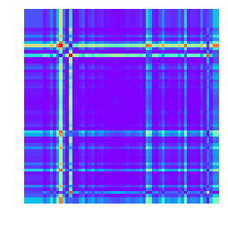

25

A_M1038MF01_1S1RNA

Drowsy True

Window Number 35

----------------------------

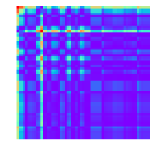

26

A_M1038MF01_1S1RNA

Drowsy True

Window Number 38

----------------------------

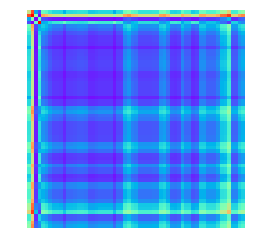

27

A_M1038MF01_2S2RNA

Drowsy True

Window Number 31

----------------------------

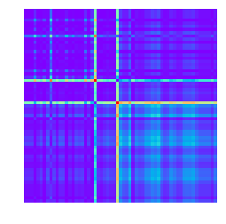

28

A_M1038MF01_2S2RNA

Drowsy True

Window Number 36

----------------------------

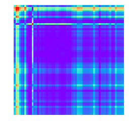

29

A_M1038MF01_2S2RNA

Drowsy True

Window Number 38

----------------------------

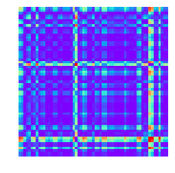

30

A_M1038MF01_3S3RNA

Drowsy True

Window Number 31

----------------------------

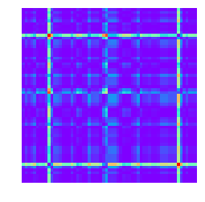

31

A_M1038MF01_3S3RNA

Drowsy True

Window Number 34

----------------------------

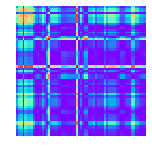

32

A_M1038MF01_3S3RNA

Drowsy True

Window Number 35

----------------------------

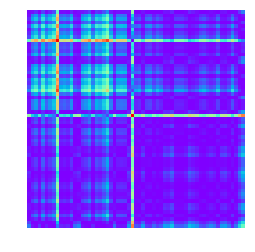

33

A_M1038MF01_3S3RNA

Drowsy True

Window Number 36

----------------------------

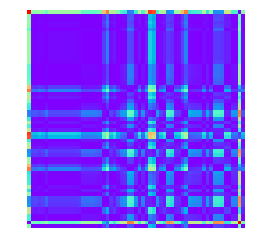

34

A_M1038MF01_3S3RNA

Drowsy True

Window Number 39

----------------------------

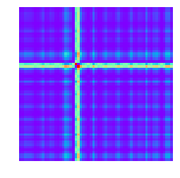

35

A_M1039MF02_3S1RNA

Drowsy True

Window Number 39

----------------------------

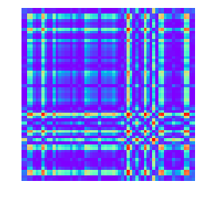

36

A_M1039MF02_3S1RNA

Drowsy True

Window Number 40

----------------------------

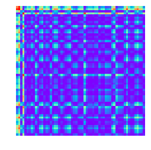

37

A_M1039MF02_3S1RNA

Drowsy True

Window Number 41

----------------------------

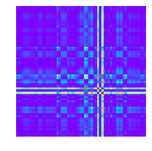

38

A_M1039MF02_3S1RNA

Drowsy True

Window Number 42

----------------------------

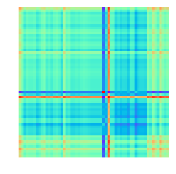

39

A_M1046MF05_2S3RNA

Drowsy True

Window Number 41

----------------------------

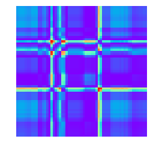

40

A_M1047MF06_2S2RNA

Drowsy True

Window Number 35

----------------------------

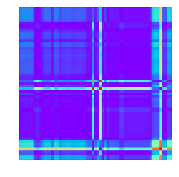

41

A_M1047MF06_2S2RNA

Drowsy True

Window Number 41

----------------------------

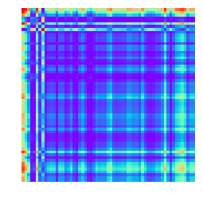

42

A_M1047MF06_3S1RNA

Drowsy True

Window Number 31

----------------------------

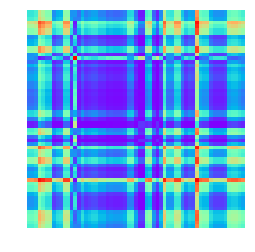

43

A_M1047MF06_3S1RNA

Drowsy True

Window Number 35

----------------------------

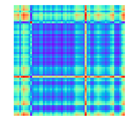

44

A_M1067OF04_2S2RNA

Drowsy True